# Rna-seq analysis

kzaitsev

March 11, 2017

```r
library(DESeq2)
library(ggplot2)
library(clusterProfiler)
library(org.Hs.eg.db)
library(pheatmap)
library(dplyr)
library(VennDiagram)
options(width=120)
```

## Файлы с которыми будем работать сегодня

В ходе данной лекции нам понадобятся следующие файлы “GSE89225_illumina_counts.csv”, “conditions.csv”, “human_mart.txt”. Для начала убедимся в том, что мы можем эти файлы прочитать. И посмотрим, что в них находится.

```r
counts <- read.csv("GSE89225_Illumina_counts.csv", row.names=1)
counts$treg_NBP_patient3 <- NULL
conditions <- read.csv("conditions.csv", row.names=1)
conditions <- conditions[-which(rownames(conditions)=="treg_NBP_patient3"),]
mart <- read.table("human_mart.txt", sep="\t", header=1, check.names = F)

print(counts[1:6, 1:2])
```

```
##                 tconv_tumor_patient10 cd177negtreg_tumor_patient10
## ENSG00000000003                   510                          935
## ENSG00000000005                    25                            1
## ENSG00000000419                   613                          818
## ENSG00000000457                   269                          587
## ENSG00000000460                    55                          142
## ENSG00000000938                    36                           69
```

```r
dim(counts)
```

```
## [1] 63677    33
```

```r
head(conditions)   #sample tissue cells
```

```
##                                            tissue                               cells
## tconv_tumor_patient10        tissue: breast tumor cell type: Conventional CD4 T cells
## cd177negtreg_tumor_patient10 tissue: breast tumor       cell type: Regulatory T cells
## cd177postreg_tumor_patient10 tissue: breast tumor       cell type: Regulatory T cells
## tconv_tumor_patient1         tissue: breast tumor cell type: Conventional CD4 T cells
## treg_tumor_patient1          tissue: breast tumor       cell type: Regulatory T cells
## tconv_NBP_patient2                    tissue: NBP cell type: Conventional CD4 T cells
```

```r
dim(conditions)
```

```
## [1] 33  2
```

```r
head(mart)
```

```
##           Gene ID Associated Gene Name Gene type EntrezGene ID
## 1 ENSG00000252303            RNU6-280P     snRNA            NA
## 2 ENSG00000281771                Y_RNA  misc_RNA            NA
## 3 ENSG00000281256         RP11-222G7.2   lincRNA            NA
## 4 ENSG00000283272      Clostridiales-1      sRNA            NA
## 5 ENSG00000280864        RP11-654C22.2   lincRNA            NA
## 6 ENSG00000280792        RP11-315F22.1   lincRNA            NA
```

```r
dim(mart)
```

```
## [1] 64101     4
```

# RNA-seq

Rna-seq steps:

- Изоляция РНК
- **Rna selection / depletion**
- **Фрагментация**
- Синтез кДНК
- Секвенирование

Rna selection / depletion:

- вся РНК
- тянем за поли(А)-хвосты (только мРНК)
- удаляем рибосомальную РНК (ribo-zero kit)
- таргетное секвенирование

Why Rna-seq?

- Не ограничены существующей сборкой и дизайном микрочипа
- Низкий фоновый сигнал (больше точность)
- Точность позволяет смотреть экспрессию отдельных изоформ

# Sanity checks

Нужно всегда проверять длины библиотек и количество rRNA reads, которые оказались в библиотеке. Количество ридов можно проверять после выравнивания или после квантификации.

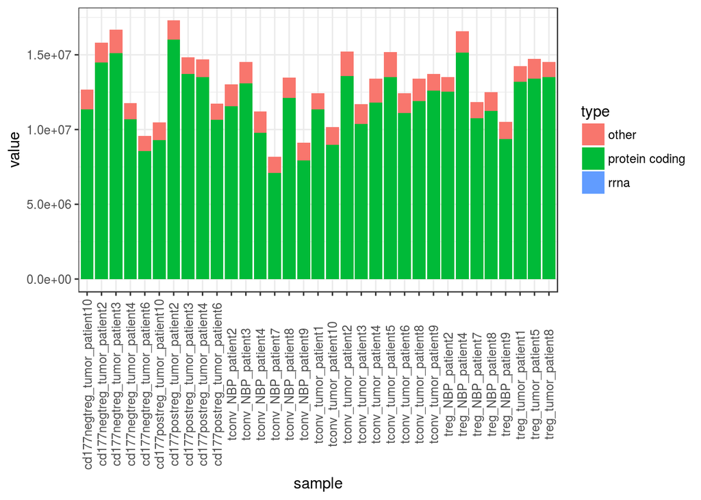

```r
proteinCoding <- mart[mart[, 3] == "protein_coding", ]
rRNA <- mart[mart[, 3] == "rRNA", ]

pcCounts <- counts[rownames(counts) %in% as.character(proteinCoding[, 1]), ] # собраны каунты для ррнк и кодирующих последовательностей
rrnaCounts <- counts[rownames(counts) %in% as.character(rRNA[, 1]), ]

sampleCount <- ncol(counts)
toPlot <- data.frame(
  sample=rep(colnames(counts), 3),
  value=c(colSums(counts) - colSums(pcCounts) - colSums(rrnaCounts),
          colSums(pcCounts),
          colSums(rrnaCounts)),
  type=c(rep("other", sampleCount),
         rep("protein coding", sampleCount),
         rep("rrna", sampleCount))
)

plot <- ggplot(data=toPlot, aes(x=sample, y=value, fill=type)) +
  geom_bar(stat="identity") + theme_bw() +
  theme(axis.text.x = element_text(angle=90, vjust=0.5))
plot
```